# Predicting Vinho Verde Wine Quality

## Univariate Analysis

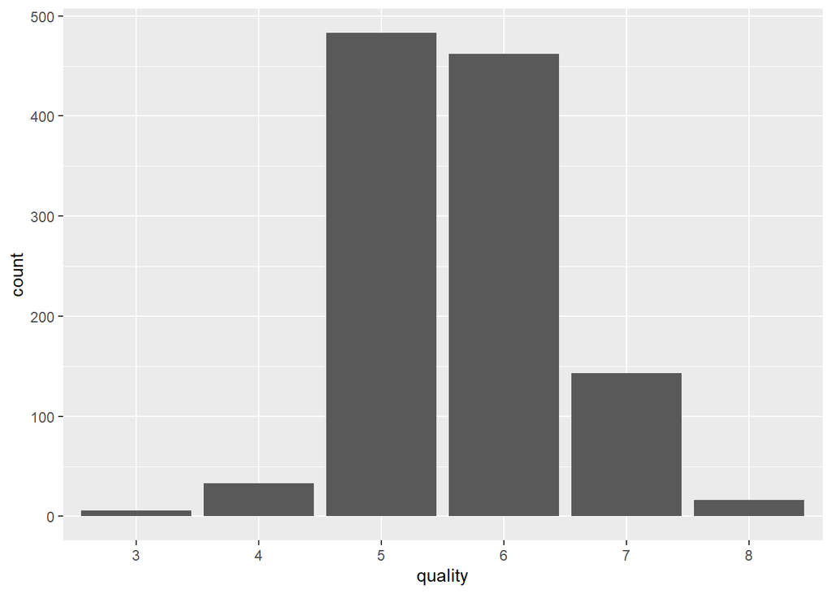

```r
wine %>% ggplot(aes(x = quality))+ geom_bar(stat = "count")
```

It appears that this dataset only consists of wine with a quality between 3 and 8. This shows we just took an average sample of wine, there are not really outliers. Furthermore, the quality scores appear to follow a normal distribution.

## Multivariate Analysis

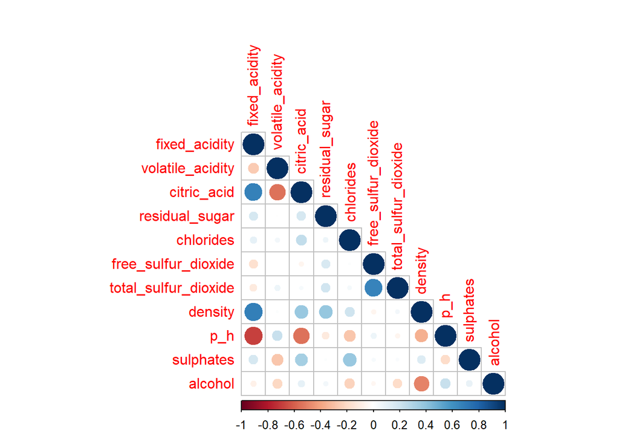

```r
wine %>% select(where(is.numeric)) %>% cor() %>% corrplot(type="lower")
```

It appears the following pairings are highly correlated: fixed acidity/citric acid, volatile acidity/citric acid, fixed acidity/density, fixed acidity/pH, citric acid/pH, free sulfur dioxide/total sulfur dioxide, and density/alcohol.

## Bivariate Analysis

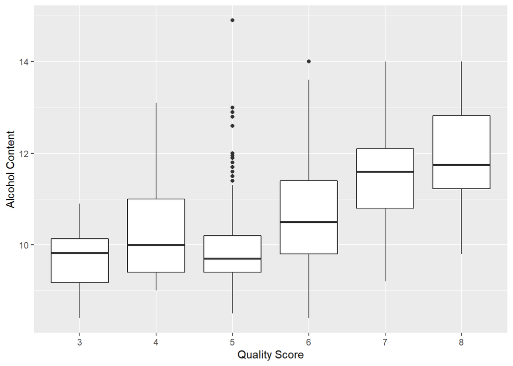

```r
wine %>%
  ggplot(aes(x = alcohol, y = quality)) +
  geom_boxplot() +
  xlab("Alcohol Content") +
  ylab("Quality Score") +
  coord_flip()
```

My initial assumption is the higher the alcohol content, the higher the quality score.

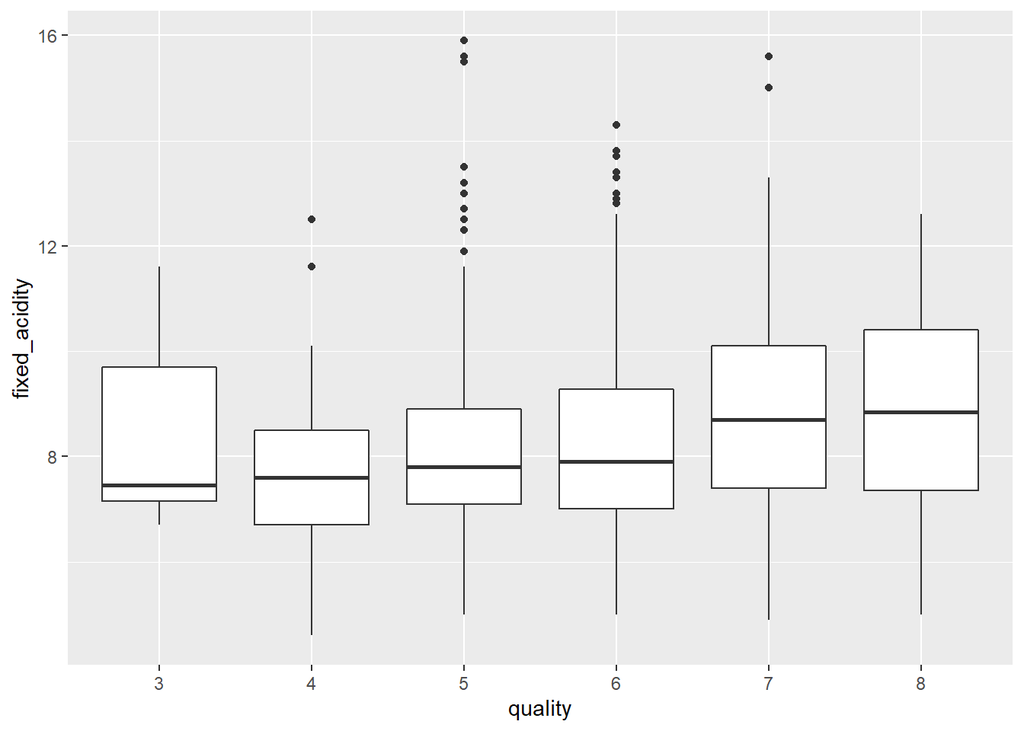

```r
wine %>%
  ggplot(aes(x = quality, y = fixed_acidity)) +
  geom_boxplot()
```

My initial assumption is that fixed acidity has some outliers when the quality score is 5 or 6, but fixed acidity does not greatly change its quality score.

# Cross Validation

```r
set.seed(1212)
wine_split <- initial_split(wine, prop = 0.80, strata = 'quality')
wine_train <- training(wine_split)
wine_test <- testing(wine_split)
dim(wine_train)
```

```
## [1] 913  12
```

```r
dim(wine_test)
```

```
## [1] 230  12
```

```r
wine_folds <- vfold_cv(wine_train, strata = quality, v = 5, repeats=5)
wine_recipe <- recipe(quality ~ fixed_acidity + volatile_acidity + citric_acid + residual_sugar + chlorides + free_sulfur_dioxide + total_sulfur_dioxide + density + p_h + sulphates + alcohol, wine_train) %>%
                  step_center(all_predictors()) %>%
                  step_scale(all_predictors())
```

The first step to building our model is setting our seed to save results. Then, I split the data into a testing and training set, with the proportion set to 0.80, stratifying on the quality variable. Then, I checked the dimensions of each data set to verify it was split correctly. I decided to employ cross-validation by folding the data into 5 partitions. I decided not to do 10 splits since there are only 1143 observations and I do not want to overfit the data. I also conducted five repeats. Then, I set up a recipe to predict to quality and centered and scaled all predictors.

# Model Fitting

Now that we’ve split our data and set up our recipe, I will fit seven different types of models to predict quality at the highest degree of accuracy.

## Naive Bayes Model

```r
naive_mod <-
  naive_Bayes()%>%
    set_mode("classification") %>%
    set_engine("klaR") %>%
    set_args(usekernel = FALSE)

naive_wf <- workflow() %>%
  add_model(naive_mod) %>%
  add_recipe(wine_recipe)

naive_fit <- fit_resamples(naive_wf, wine_folds)

collect_metrics(naive_fit)
```

```
## # A tibble: 2 x 6
##   .metric  .estimator  mean     n std_err .config
##   <chr>    <chr>      <dbl> <int>   <dbl> <chr>
## 1 accuracy multiclass 0.507    25 0.00798 Preprocessor1_Model1
## 2 roc_auc  hand_till  0.706    25 0.0122  Preprocessor1_Model1
```

## Support Vector Machine (SVM) with Linear Kernel Model

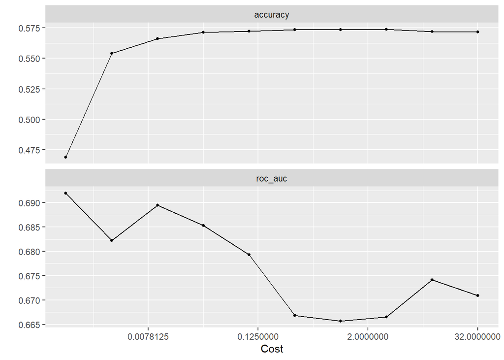

```r
svm_linear_mod <- svm_poly(degree = 1) %>%
  set_mode("classification") %>%
  set_engine("kernlab", scaled = FALSE)

svm_linear_wf <- workflow() %>%
  add_model(svm_linear_mod %>% set_args(cost = tune())) %>%
  add_recipe(wine_recipe)

svm_grid <- grid_regular(cost(), levels = 10)

svm_tune <- tune_grid(
  svm_linear_wf,
  resamples = wine_folds,
  grid = svm_grid
)

autoplot(svm_tune)
```

```r
show_best(svm_tune)
```

```
## # A tibble: 5 x 7
##       cost .metric .estimator  mean     n std_err .config
##      <dbl> <chr>   <chr>      <dbl> <int>   <dbl> <chr>
## 1 0.000977 roc_auc hand_till  0.692    25 0.00845 Preprocessor1_Model01
## 2 0.00984  roc_auc hand_till  0.689    25 0.00836 Preprocessor1_Model03
## 3 0.0312   roc_auc hand_till  0.685    25 0.00807 Preprocessor1_Model04
## 4 0.00310  roc_auc hand_till  0.682    25 0.00813 Preprocessor1_Model02
## 5 0.0992   roc_auc hand_till  0.679    25 0.00788 Preprocessor1_Model05
```

The next model I decided to fit is a Support Vector Classifier with Linear Kernel. I decided to set up a grid to tune the cost parameter. It looks like the higher the cost, the higher accuracy. However, in the case of the roc_auc values, its performance is more varied, with it peaking at a lower cost. It appears that the best cost is 0.000977, yielding a value of 0.692 and a standard error of 0.00845.

## SVM with Non-Linear Kernel Model

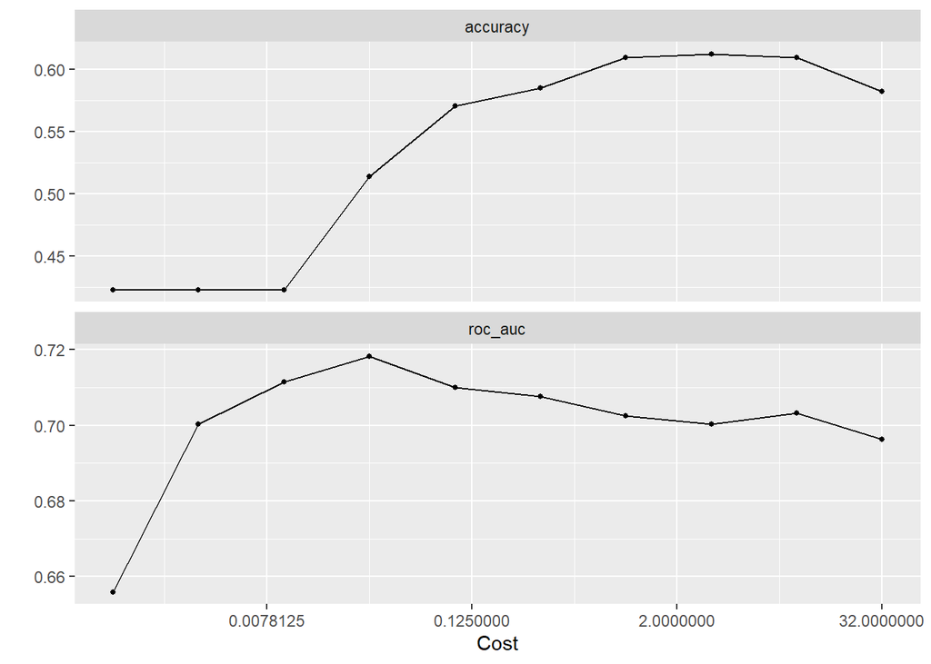

```r
svm_nonlinear_mod <- svm_rbf() %>%
  set_mode("classification") %>%
  set_engine("kernlab")

svm_nonlinear_wf <- workflow() %>%
  add_model(svm_nonlinear_mod %>% set_args(cost = tune())) %>%
  add_recipe(wine_recipe)

svm_gridn <- grid_regular(cost(), levels = 10)

svm_tunen <- tune_grid(
  svm_nonlinear_wf,
  resamples = wine_folds,
  grid = svm_gridn
)

autoplot(svm_tunen)
```

```r
show_best(svm_tunen)
```

```
## # A tibble: 5 x 7
##       cost .metric .estimator  mean     n std_err .config
##      <dbl> <chr>   <chr>      <dbl> <int>   <dbl> <chr>
## 1  0.0312  roc_auc hand_till  0.718    25 0.00812 Preprocessor1_Model04
## 2  0.00984 roc_auc hand_till  0.711    25 0.00815 Preprocessor1_Model03
## 3  0.0992  roc_auc hand_till  0.710    25 0.00946 Preprocessor1_Model05
## 4  0.315   roc_auc hand_till  0.708    25 0.00961 Preprocessor1_Model06
## 5 10.1     roc_auc hand_till  0.703    25 0.00968 Preprocessor1_Model09
```

## K NNearest Neighbors Model

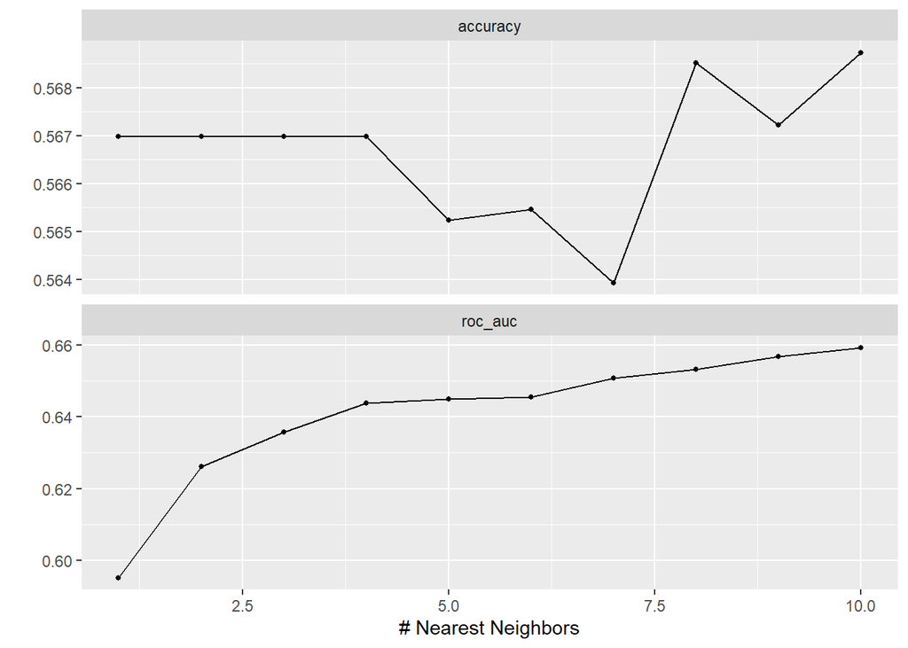

```r
knn_mod <-
  nearest_neighbor(neighbors = tune())%>%
    set_mode("classification") %>%
    set_engine("kknn")

knn_wf <- workflow() %>%
  add_model(knn_mod) %>%
  add_recipe(wine_recipe)

knn_grid <- grid_regular(neighbors(), levels = 10)

knn_tune <- tune_grid(
  knn_wf,
  resamples = wine_folds,
  grid = knn_grid
)

autoplot(knn_tune)
```

```r
show_best(knn_tune)
```

```
## # A tibble: 5 x 7
##   neighbors .metric .estimator  mean     n std_err .config
##       <int> <chr>   <chr>      <dbl> <int>   <dbl> <chr>
## 1        10 roc_auc hand_till  0.659    25 0.00717 Preprocessor1_Model10
## 2         9 roc_auc hand_till  0.657    25 0.00736 Preprocessor1_Model09
## 3         8 roc_auc hand_till  0.653    25 0.00704 Preprocessor1_Model08
## 4         7 roc_auc hand_till  0.651    25 0.00671 Preprocessor1_Model07
## 5         6 roc_auc hand_till  0.645    25 0.00655 Preprocessor1_Model06
```

## Random Forest Model

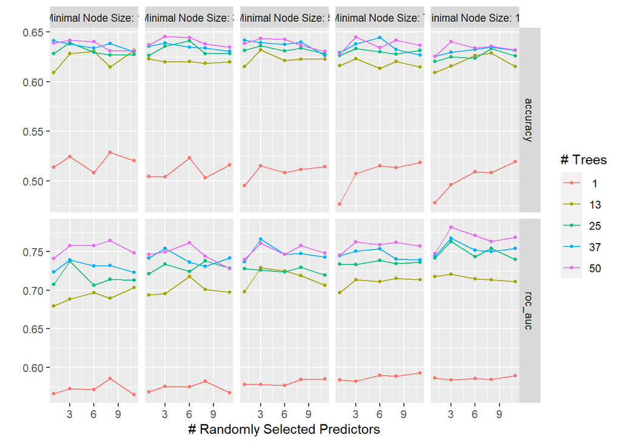

```r
forest_model <-
  rand_forest(trees = tune(),
              min_n = tune(),
              mtry = tune()) %>%
              set_mode("classification") %>%
              set_engine("ranger", importance = 'impurity')

forest_wf <- workflow() %>%
  add_model(forest_model) %>%
  add_recipe(wine_recipe)

param_gridf <- grid_regular(min_n(range = c(1,10)), trees(range = c(1,50)), mtry(range = c(1,11)), levels= 5)

tune_resf <- tune_grid(
  forest_wf,
  resamples = wine_folds,
  grid = param_gridf
)

autoplot(tune_resf)
```

```r
show_best(tune_resf)
```

```
## # A tibble: 5 x 9
##    mtry trees min_n .metric .estimator  mean     n std_err .config
##   <int> <int> <int> <chr>   <chr>      <dbl> <int>   <dbl> <chr>
## 1     3    50    10 roc_auc hand_till  0.782    25 0.00788 Preprocessor1_Model0~
## 2     6    50    10 roc_auc hand_till  0.771    25 0.00668 Preprocessor1_Model0~
## 3    11    50    10 roc_auc hand_till  0.769    25 0.00890 Preprocessor1_Model1~
## 4     3    37    10 roc_auc hand_till  0.767    25 0.00901 Preprocessor1_Model0~
## 5     3    37     5 roc_auc hand_till  0.766    25 0.00907 Preprocessor1_Model0~
```

Now, I will fit a forest model to the training data. The parameters I am tuning are the minimal node size (min_n), the number of predictors in each fold (mtry), and the number of trees. It looks like the higher number of trees, the better performance for roc_auc and accuracy. In both cases, the fewer number of predictors (mtry), the better. For minimal node size, it varies without much change in performance, but it appears the higher number the better. The best forest model has a 3 mtry value, 50 trees, and 10 minimal nodes to yield a roc_auc value of 0.782 and a standard error of 0.00788.

## Bagged Model

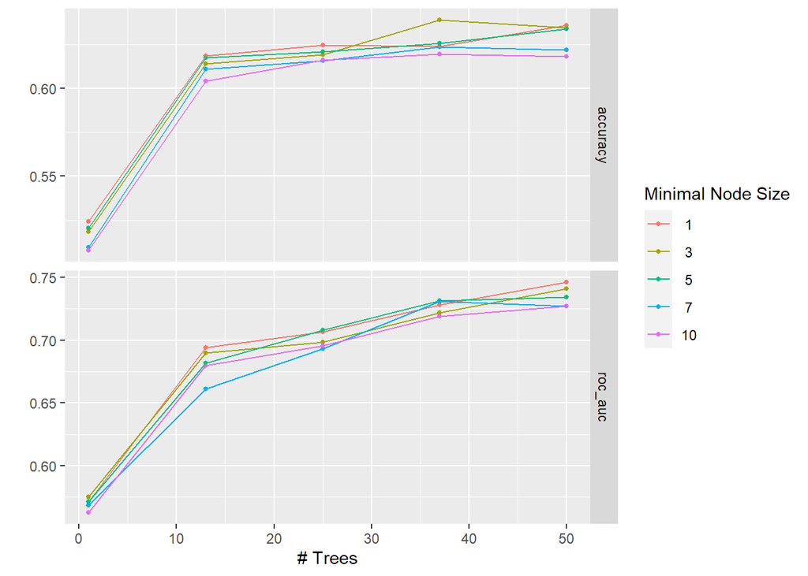

```r
bagging_mod <- rand_forest(mtry = 11, min_n = tune(), trees = tune()) %>%
  set_engine("randomForest", importance = TRUE) %>%
  set_mode("classification")

bagging_wf <- workflow() %>%
  add_model(bagging_mod) %>%
  add_recipe(wine_recipe)

param_gridbag <- grid_regular(min_n(range = c(1,10)), trees(range = c(1,50)), levels= 5)

tune_bag <- tune_grid(
  bagging_wf,
  resamples = wine_folds,
  grid = param_gridbag
)

autoplot(tune_bag)
```

```r
show_best(tune_bag)
```

```
## # A tibble: 5 x 8
##   trees min_n .metric .estimator  mean     n std_err .config
##   <int> <int> <chr>   <chr>      <dbl> <int>   <dbl> <chr>
## 1    50     1 roc_auc hand_till  0.746    25 0.00968 Preprocessor1_Model21
## 2    50     3 roc_auc hand_till  0.741    25 0.00868 Preprocessor1_Model22
## 3    50     5 roc_auc hand_till  0.734    25 0.00945 Preprocessor1_Model23
## 4    37     5 roc_auc hand_till  0.731    25 0.00963 Preprocessor1_Model18
## 5    37     7 roc_auc hand_till  0.731    25 0.00951 Preprocessor1_Model19
```